# STAT295 HOMEWORK-2

Ali Altuntaş, Rubar Akyıldız

2024-05-26

# HOMEWORK 2

## Question 1:

### i)

```r
data <- read.csv("social_network_ad.csv")
head(data)
```

```
##   X  User.ID Gender Age EstimatedSalary Purchased GiftTicket
## 1 1 15624510   Male  19           19000         0          0
## 2 2 15810944   Male  35           20000         0          1
## 3 3 15668575 Female  26           43000         0          0
## 4 4 15603246 Female  27           57000         0          0
## 5 5 15804002   Male  19           76000         0          0
## 6 6 15728773   Male  27           58000         0          0
```

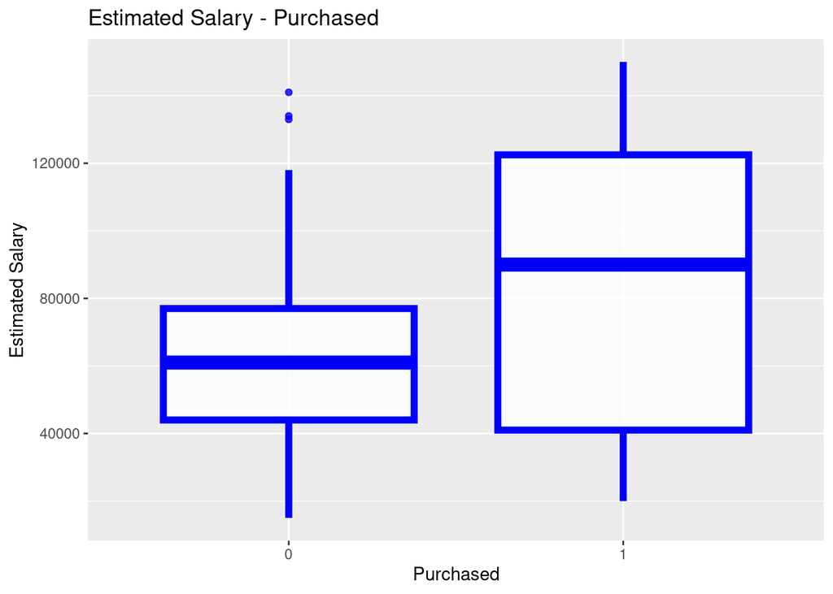

```r
ggplot(data, aes(y=EstimatedSalary, x= as.factor(Purchased)))+
  geom_boxplot(color= "blue",
             size=2,
             alpha=.8) +labs(x="Purchased",
                             y="Estimated Salary",
                             title ="Estimated Salary - Purchased")
```

A brief commentary about the dataset:

#### General Structure:

**Columns**:

- **User.ID:** This column is an integer and it is used to give each customer a unique identity.
- **Gender:** This column is a string value to distinguish genders of given customers.
- **Age:** This is an integer column that indicates the age of the individuals.
- **GiftTicket:** This column is a binary variable that shows whether a gift coucher was issued or not.
- **Purchased:** This column is a binary variable that shows whether the product was puchased or not.
- **EstimatedSalary:** This column is an integer variable that gives the estimated salaries of each individual.

#### Characteristics:

**Data Type**:

- The dataset includes both numerical and categorical data.
- The `User.ID`, `Age`, `GiftTicket`, `EstimatedSalary` and `Purchased` columns are numerical.
- The `Gender` column is categorical.

**Size and Unique Values**:

- Assuming `User.ID` is unique for each row, it implies that the dataset has a number of rows equal to the number of unique customers.
- `Gender` is likely to have a small number of unique values, typically two (male and female).
- `Age` may have a wide range of values depending on the demographic spread of the dataset.
- `EstimatedSalary` may have a wide range of values depending on the demographic spread of the dataset.
- `GiftTicket` and `Purchased` being binary, each will have two unique values.

### ii)

```r
regmodel <- glm(Purchased ~ EstimatedSalary, data= data, family = binomial())
 summary(regmodel)
```

```
##
## Call:
## glm(formula = Purchased ~ EstimatedSalary, family = binomial(),
##     data = data)
##
## Coefficients:
##                   Estimate Std. Error z value Pr(>|z|)
## (Intercept)     -2.323e+00  2.855e-01  -8.134 4.14e-16 ***
## EstimatedSalary  2.388e-05  3.516e-06   6.790 1.12e-11 ***
## ---
## Signif. codes:  0 '***' 0.001 '**' 0.01 '*' 0.05 '.' 0.1 ' ' 1
##
## (Dispersion parameter for binomial family taken to be 1)
##
##     Null deviance: 521.57  on 399  degrees of freedom
## Residual deviance: 467.73  on 398  degrees of freedom
## AIC: 471.73
##
## Number of Fisher Scoring iterations: 4
```

```r
exp(regmodel$coefficients[2])
```

```
## EstimatedSalary
##        1.000024
```

As the odds ratio for Estimated Salary function is slightly greater than 1, we have positive association between purchasing and probabity of purchasing.

```r
est_22k <- data.frame(EstimatedSalary = 22000)
predict(regmodel, est_22k, type="response")
```

```
##         1
## 0.1421615
```

According to our predictions, the probability of an individual with $22.000 salary to purchase the product is 0.142.

### iv)

```r
data$Gender[data$Gender == "Male"] <- 1
data$Gender[data$Gender == "Female"] <- 0
data$Gender <- as.factor(data$Gender)

model_gender <- glm(Purchased ~ Gender, data = data, family = binomial(link = logit))
exp(model_gender$coefficients[2])
```

```
##   Gender1
## 0.8373626
```

```r
summary(model_gender)
```

```
##
## Call:
## glm(formula = Purchased ~ Gender, family = binomial(link = logit),
##     data = data)
##
## Coefficients:
##             Estimate Std. Error z value Pr(>|z|)
## (Intercept)  -0.5004     0.1444  -3.464 0.000531 ***
## Gender1      -0.1775     0.2091  -0.849 0.395858
## ---
## Signif. codes:  0 '***' 0.001 '**' 0.01 '*' 0.05 '.' 0.1 ' ' 1
##
## (Dispersion parameter for binomial family taken to be 1)
##
##     Null deviance: 521.57  on 399  degrees of freedom
## Residual deviance: 520.85  on 398  degrees of freedom
## AIC: 524.85
##
## Number of Fisher Scoring iterations: 4
```

### v)

```r
model_gtp <- glm(Purchased ~ GiftTicket, data = data, family = binomial())
exp(model_gtp$coefficients[2])
```

```
## GiftTicket
##   15.77303
```

```r
model_gtp %>% summary()
```

```
##
## Call:
## glm(formula = Purchased ~ GiftTicket, family = binomial(), data = data)
##
## Coefficients:
##             Estimate Std. Error z value Pr(>|z|)
## (Intercept)  -2.8622     0.4197  -6.819 9.17e-12 ***
## GiftTicket    2.7583     0.4360   6.327 2.50e-10 ***
## ---
## Signif. codes:  0 '***' 0.001 '**' 0.01 '*' 0.05 '.' 0.1 ' ' 1
##
## (Dispersion parameter for binomial family taken to be 1)
##
##     Null deviance: 521.57  on 399  degrees of freedom
## Residual deviance: 446.54  on 398  degrees of freedom
## AIC: 450.54
##
## Number of Fisher Scoring iterations: 5
```

### vi)

```r
data.frame()
```

```
## data frame with 0 columns and 0 rows
```

```r
#gift_yes <- data.frame(as.numeric(GiftTicket == 1))
#gift_no <- data.frame(GiftTicket == 0)
#predict(model_gtp, gift_yes, type="response")
```